# Class 08

Gabriela Goldberg

4/26/2019

## Kmeans clustering

Generate some example data for clustering

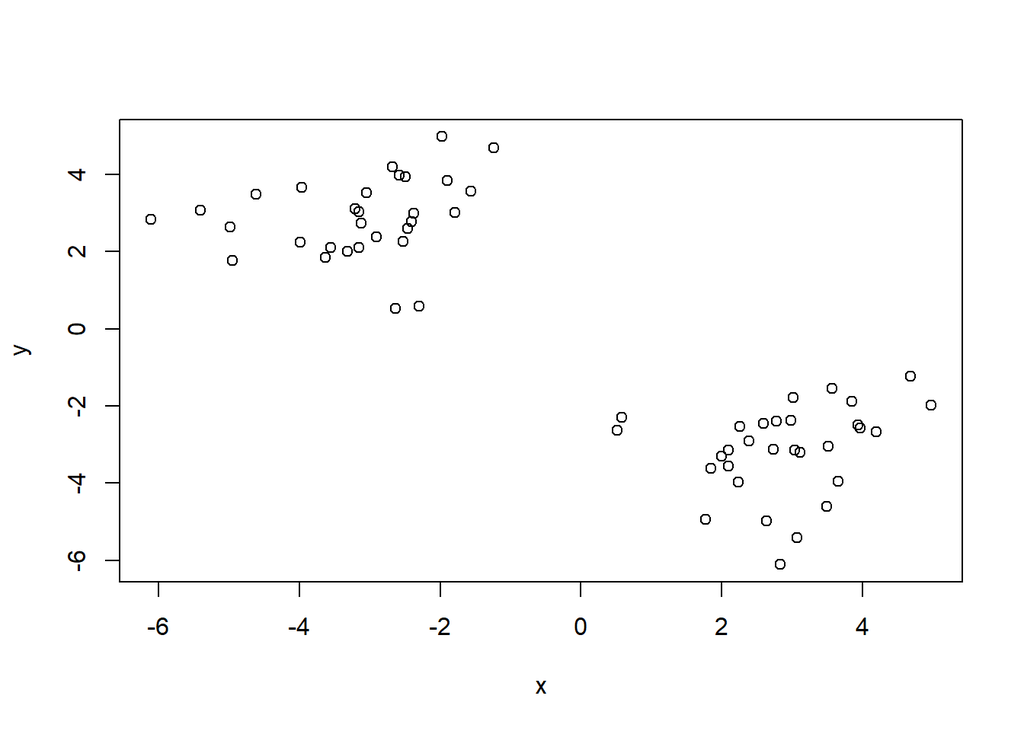

```r
tmp <- c(rnorm(30,-3), rnorm(30,3))
x <- cbind(x=tmp, y=rev(tmp))

plot(x)
```

Use the kmeans() function setting k to 2 and nstart=20 Inspect/print the results

```r
rand_kmeans <- kmeans(x, 2, nstart = 20)
point_allocation <- rand_kmeans$cluster
cluster_size <- rand_kmeans$size
cluster_centers <- rand_kmeans$centers
```

> Q. How many points are in each cluster? 30 points in each cluster

> Q. What ‘component’ of your result object details - cluster size? SIZE - cluster assignment/membership? CLUSTER - cluster center? CENTER

Plot x colored by the kmeans cluster assignment and add cluster centers as blue points

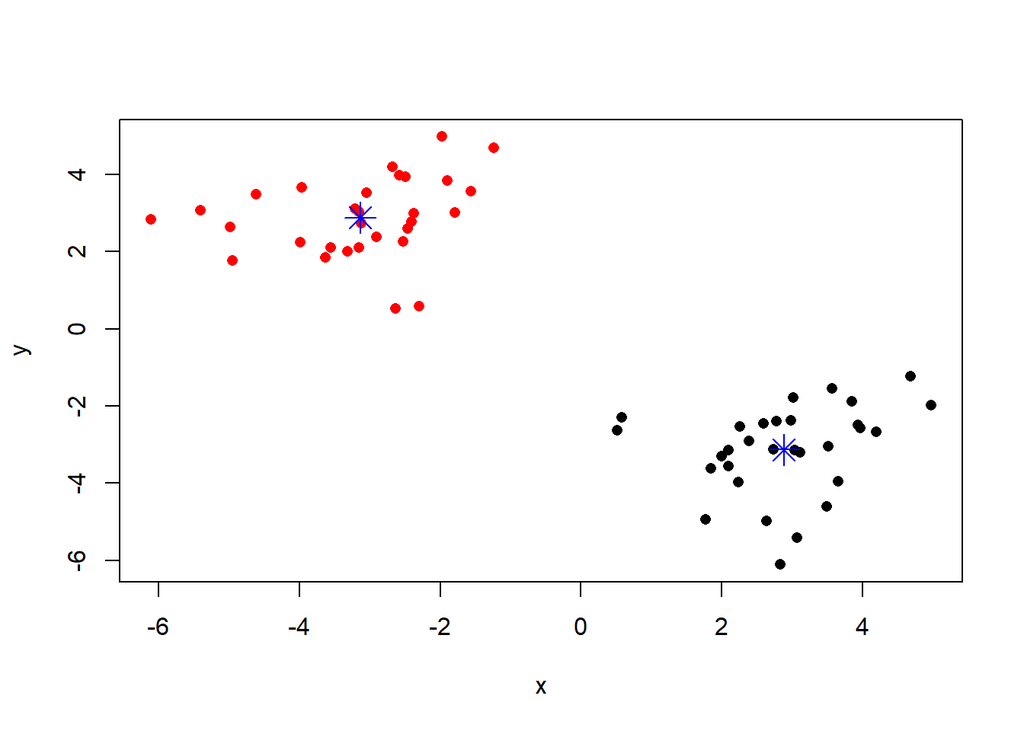

```r
plot(x, type = "p", col = point_allocation, pch = 16)
points(cluster_centers, type = "p", col = "blue", pch = 8, cex = 2)
```

## Hierarchical clustering

Here we don’t have to spell out “K” the number of clusters before-hand, but we do have to give it a distance matrix as input.

```r
d <- dist(x)
hc <- hclust(d)
hc
```

```
##
## Call:
## hclust(d = d)
##
## Cluster method   : complete
## Distance         : euclidean
## Number of objects: 60
```

Let’s plot the results

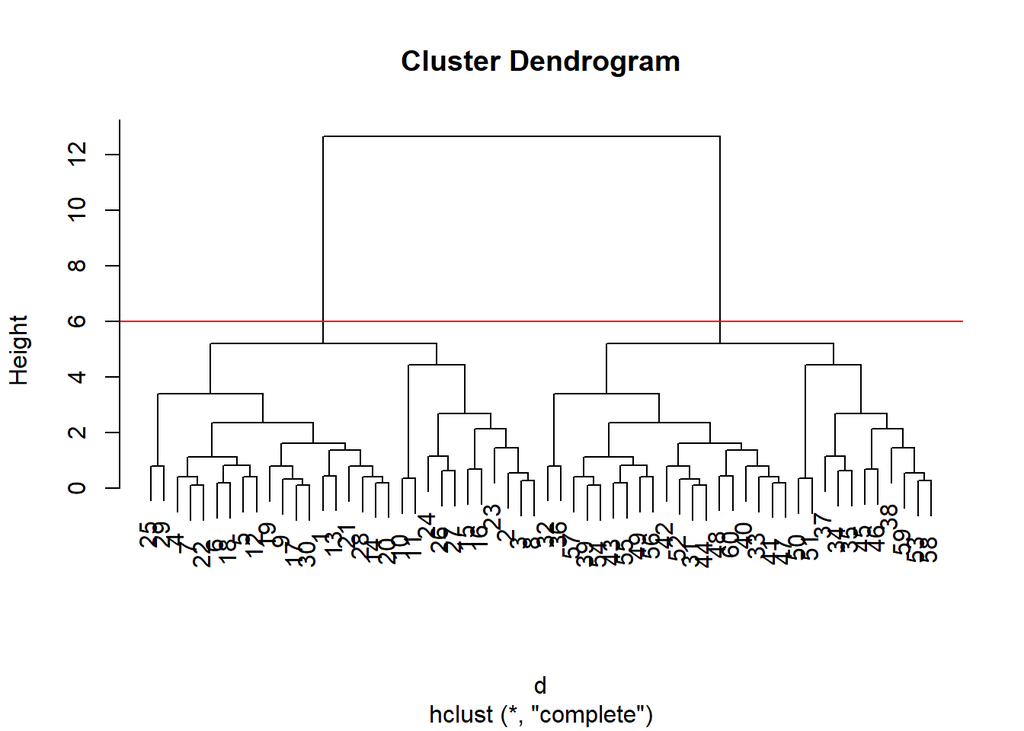

```r
plot(hc)
abline(h = 6, col = "red")
```

```r
cutree(hc, h = 6)
```

```
##  [1] 1 1 1 1 1 1 1 1 1 1 1 1 1 1 1 1 1 1 1 1 1 1 1 1 1 1 1 1 1 1 2 2 2 2 2
## [36] 2 2 2 2 2 2 2 2 2 2 2 2 2 2 2 2 2 2 2 2 2 2 2 2 2
```

Cut into two groups

```r
gp2 <- cutree(hc, k = 2)
```

Cut into three groups

```r
gp3 <- cutree(hc, k = 3)
```

Compare both clusterings

```r
table(gp2, gp3)
```

```
##    gp3
## gp2  1  2  3
##   1 30  0  0
##   2  0 19 11
```

Our Turn!!!

Step 1. Generate some example data for clustering

```r
x <- rbind(
 matrix(rnorm(100, mean=0, sd = 0.3), ncol = 2), # c1
 matrix(rnorm(100, mean = 1, sd = 0.3), ncol = 2), # c2
 matrix(c(rnorm(50, mean = 1, sd = 0.3), # c3
 rnorm(50, mean = 0, sd = 0.3)), ncol = 2))
colnames(x) <- c("x", "y")
```

Step 2. Plot the data without clustering

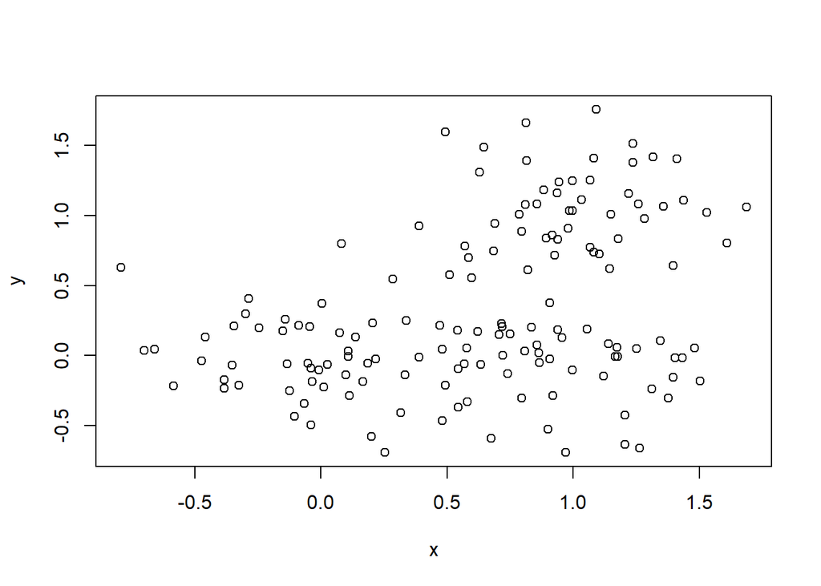

```r
plot(x)
```

Step 3. Generate colors for known clusters (just so we can compare to hclust results)

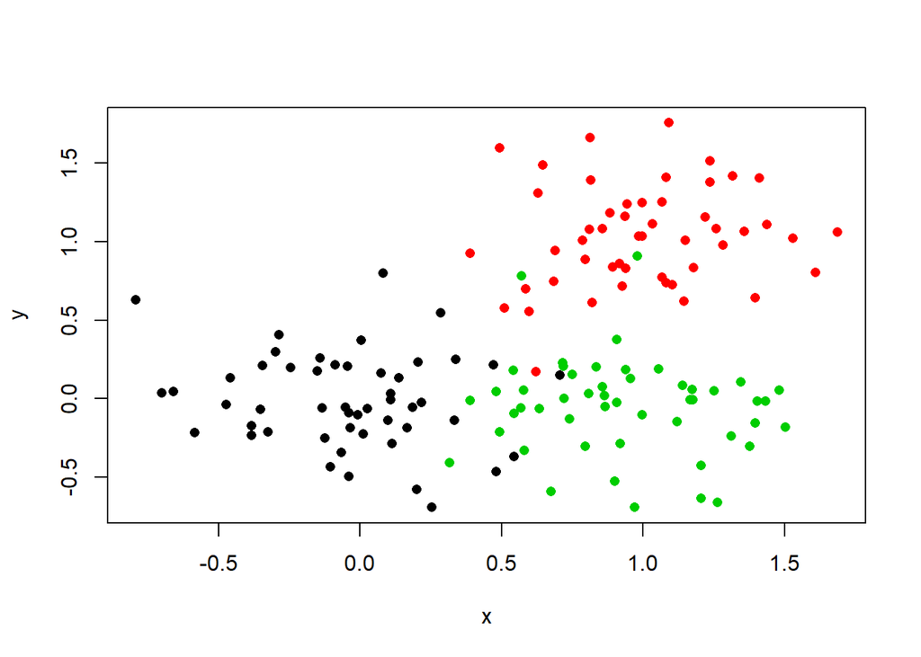

```r
col <- as.factor( rep(c("c1","c2","c3"), each=50) )
plot(x, col=col, pch = 16)
```

> Q. Use the dist(), hclust(), plot() and cutree() functions to return 2 and 3 clusters

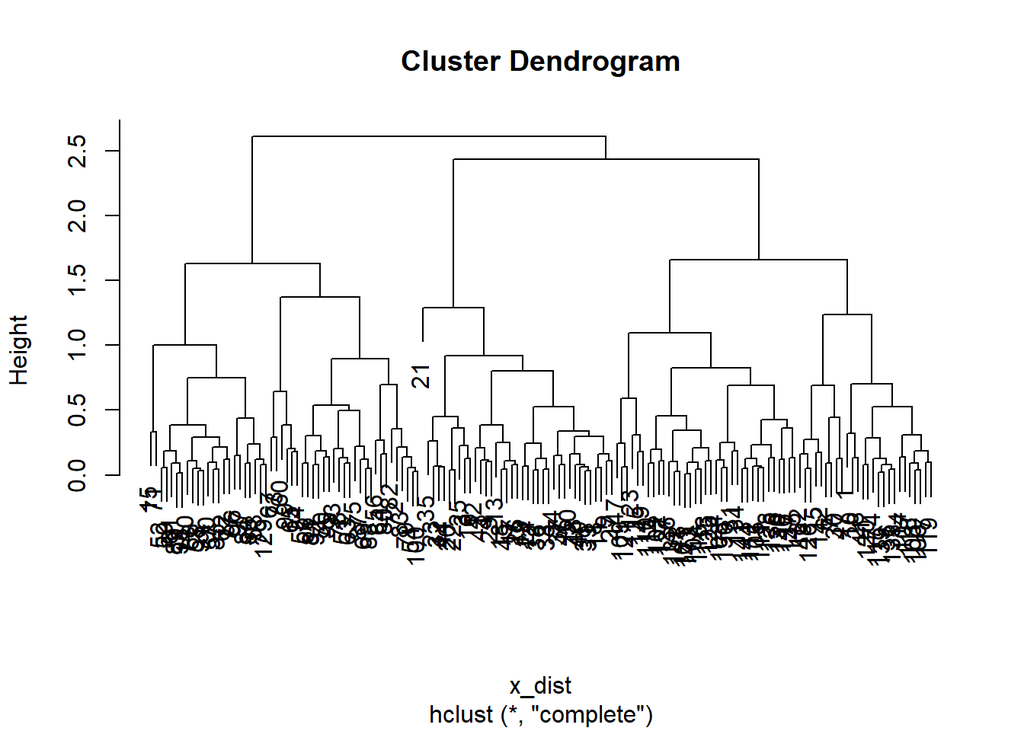

```r
x_dist <- dist(x)
x_hc <- hclust(x_dist)
plot(x_hc)
```

```r
x_2grp <- cutree(x_hc, k = 2)
x_3grp <- cutree(x_hc, k = 3)
```

> Q. How does this compare to your known ‘col’ groups?

```r
table(x_2grp)
```

```
## x_2grp
##  1  2
## 98 52
```

```r
table(x_3grp)
```

```
## x_3grp
##  1  2  3
## 61 37 52
```

```r
table(x_2grp, x_3grp)
```

```
##       x_3grp
## x_2grp  1  2  3
##      1 61 37  0
##      2  0  0 52
```

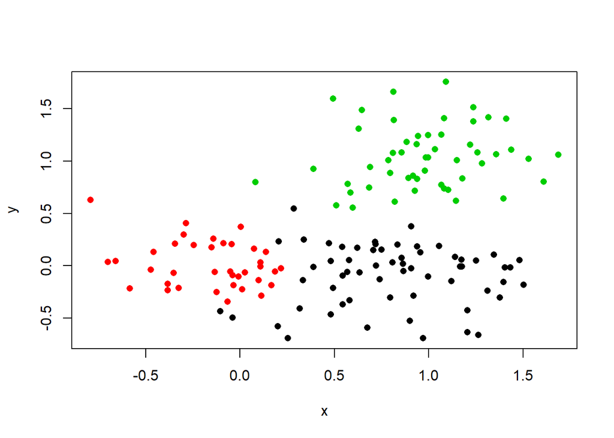

```r
plot(x, col = x_3grp, pch = 16)
```

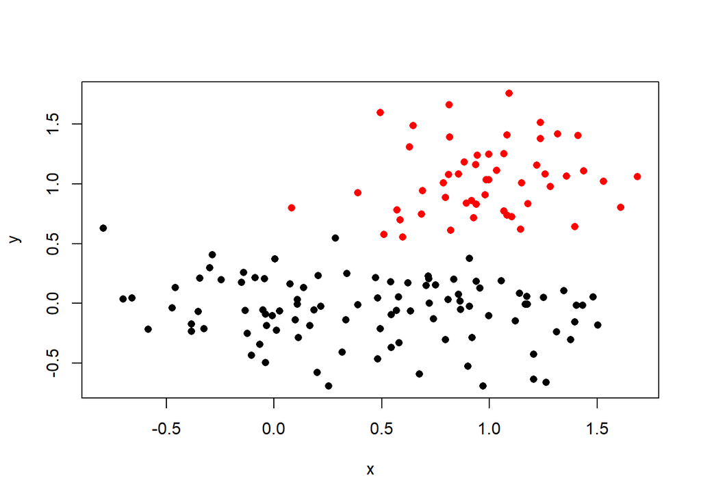

```r
plot(x, col = x_2grp, pch = 16)
```

## Principal Component Analysis (PCA)

```r
mydata <- read.csv("https://tinyurl.com/expression-CSV",
 row.names=1)
head(mydata)
```

```
##        wt1 wt2  wt3  wt4 wt5 ko1 ko2 ko3 ko4 ko5
## gene1  439 458  408  429 420  90  88  86  90  93
## gene2  219 200  204  210 187 427 423 434 433 426
## gene3 1006 989 1030 1017 973 252 237 238 226 210
## gene4  783 792  829  856 760 849 856 835 885 894
## gene5  181 249  204  244 225 277 305 272 270 279
## gene6  460 502  491  491 493 612 594 577 618 638
```

There are 100 genes in this dataset.